# Module 3: Multiview Mediation with Zentangler

ISMB 2026 Tutorial VT4: Multimodal Integration and Multimodal Causal Inference using R/Bioconductor

Saptarshi Roy, Sreya Sarkar, Himel Mallick

July 06, 2026

# 1 Overview

Module 3 asks a mechanistic question: when an exposure influences an outcome, which molecular features sit on the path between them, and in which view do they live? This is a mediation question. An exposure `X` may influence many candidate mediators spread across several omics views, and those mediators may in turn be associated with an outcome `Y`.

This short tutorial uses an autism spectrum disorder (ASD) example to compare two mediation workflows:

1. `HIMA2`, a single-view method, run one omics view at a time.
2. `Zentangler`, run jointly across all ASD omics views together.

For each mediator feature `j` in view `k`, Zentangler reports an A-path coefficient `a` (does `X` associate with mediator `j`?), a B-path coefficient `b` (does mediator `j` associate with `Y` after accounting for `X` and the other selected mediators?), and a ranking score `score = a * b`. Larger absolute scores rank higher.

This focused tutorial uses:

- the ASD example data shipped in `data/`
- one symptom outcome: `ABC`
- one time contrast: `T0` versus `T1`
- a continuous outcome only

# 2 Data Used

The modalities used are:

```
Species
KOs
Fecal Metabolites
Plasma Metabolites
```

The exposure is treatment time:

```
X = 0 for baseline T0
X = 1 for follow-up T1
```

The outcome is the `ABC` symptom score.

# 3 Packages

```r
library(Zentangler)
library(MultiAssayExperiment)
library(SummarizedExperiment)
library(S4Vectors)

# HIMA is needed only for the single-view HIMA2 comparator.
if (!requireNamespace("HIMA", quietly = TRUE)) {
  stop("Install HIMA before running the HIMA2 part of this tutorial.")
}
```

# 4 Load The ASD Data

We load the ASD `.RData` files directly from the course [GitHub repository](https://github.com/himelmallick/ISMB2026MultimodalShortCourse), exactly as Module 1 loads its datasets. Nothing depends on the working directory, so the notebook knits from anywhere and no environment variable needs to be set.

Each omics `.RData` file contains a `pcl` list with `features`, `metadata`, and `features_metadata`. The symptom file contains a long table with columns `ID`, `Symptom`, `Timepoint`, and `Score`.

```r
data_url <- paste0(
  "https://github.com/himelmallick/ISMB2026MultimodalShortCourse/",
  "raw/refs/heads/master/data/"
)

## Read a `pcl` object straight from the repository.
read_pcl <- function(file) {
  e <- new.env(parent = emptyenv())
  con <- url(paste0(data_url, file), open = "rb")
  on.exit(close(con), add = TRUE)
  load(con, envir = e)
  if (!exists("pcl", envir = e, inherits = FALSE)) {
    stop("Expected object `pcl` in ", file)
  }
  get("pcl", envir = e)
}

omics_files <- c(
  species = "ASD_Species.RData",
  kos = "ASD_KOs.RData",
  fecal_metabolites = "ASD_fecalMetabolites.RData",
  plasma_metabolites = "ASD_plasmaMetabolites.RData"
)

omics <- lapply(omics_files, read_pcl)
names(omics) <- names(omics_files)
symptoms <- read_pcl("ASD_Symptoms.RData")$features
```

# 5 Build A MultiAssayExperiment

For the ASD tutorial, the exposure is treatment time (`X = 0` at baseline `T0`, `X = 1` at follow-up `T1`) and the outcome is one symptom score. The helper below builds a `MultiAssayExperiment` for one contrast and one symptom, using subject-time IDs as primary sample IDs so the modalities and phenotype table are aligned.

```r
build_asd_mae <- function(
  omics,
  symptoms,
  contrast = c("T1", "T2"),
  symptom = "ABC",
  views = names(omics),
  fill_zero = TRUE,
  scale_features = TRUE
) {
  ## Timepoint labels differ between the omics and symptom tables, so each is
  ## mapped onto a common T0/T1/T2 vocabulary before they are joined.
  norm_omics_time <- function(x) {
    z <- toupper(trimws(as.character(x)))
    out <- rep(NA_character_, length(z))
    out[z %in% c("1", "0", "T0", "BASELINE")] <- "T0"
    out[z %in% c("3", "10", "T1", "10WK", "WEEK10", "MTT_10WK")] <- "T1"
    out[z %in% c("2YR", "2YR_FOLLOWUP", "T2", "YEAR2", "2Y")] <- "T2"
    out
  }
  norm_symptom_time <- function(x) {
    z <- toupper(trimws(as.character(x)))
    out <- rep(NA_character_, length(z))
    out[z %in% c("T0", "BASELINE", "0")] <- "T0"
    out[z %in% c("T1", "10", "10WK", "WEEK10", "1")] <- "T1"
    out[z %in% c("T2", "2YR", "2YR_FOLLOWUP", "2")] <- "T2"
    out
  }
  ## subject + timepoint is the primary key linking modalities to the phenotype.
  primary_id <- function(subject_id, timepoint) {
    paste(as.character(subject_id), as.character(timepoint), sep = "__")
  }
  ## Coerce a view to a numeric matrix, drop zero-variance features, scale.
  feature_matrix <- function(x) {
    x <- as.data.frame(x, check.names = FALSE, stringsAsFactors = FALSE)
    mat <- as.matrix(data.frame(lapply(x, function(z) {
      suppressWarnings(as.numeric(as.character(z)))
    }), check.names = FALSE))
    colnames(mat) <- colnames(x)
    rownames(mat) <- rownames(x)
    storage.mode(mat) <- "numeric"
    if (fill_zero) mat[!is.finite(mat)] <- 0
    keep <- apply(mat, 2, function(z) stats::var(z, na.rm = TRUE) > 0)
    mat <- mat[, keep, drop = FALSE]
    if (scale_features && ncol(mat) > 0) {
      mat <- scale(mat)
      mat[!is.finite(mat)] <- 0
    }
    mat
  }

  contrast <- match.arg(contrast)
  keep_times <- c("T0", contrast)

  sym <- as.data.frame(symptoms, check.names = FALSE, stringsAsFactors = FALSE)
  sym$time_norm <- norm_symptom_time(sym$Timepoint)
  sym <- sym[sym$Symptom == symptom & sym$time_norm %in% keep_times, , drop = FALSE]
  sym$primary <- primary_id(sym$ID, sym$time_norm)
  sym$X <- as.integer(sym$time_norm == contrast)
  sym$Y <- suppressWarnings(as.numeric(as.character(sym$Score)))
  sym <- sym[is.finite(sym$Y), c("primary", "ID", "time_norm", "X", "Y"), drop = FALSE]
  rownames(sym) <- sym$primary

  experiments <- list()
  sample_map_rows <- list()

  for (view in views) {
    pcl <- omics[[view]]
    meta <- as.data.frame(pcl$metadata, check.names = FALSE, stringsAsFactors = FALSE)
    feat <- as.data.frame(pcl$features, check.names = FALSE, stringsAsFactors = FALSE)

    meta$time_norm <- norm_omics_time(meta$Time_point)
    meta$primary <- primary_id(meta[["Subject ID"]], meta$time_norm)
    rownames(feat) <- meta$primary

    idx <- meta$time_norm %in% keep_times & meta$primary %in% sym$primary
    if (!any(idx)) next

    mat <- feature_matrix(feat[idx, , drop = FALSE])
    if (nrow(mat) < 4 || ncol(mat) < 2) next

    # SummarizedExperiment stores assays as features x samples.
    experiments[[view]] <- SummarizedExperiment::SummarizedExperiment(
      assays = list(abundance = t(mat))
    )
    sample_map_rows[[view]] <- data.frame(
      assay = view,
      primary = rownames(mat),
      colname = rownames(mat),
      stringsAsFactors = FALSE
    )
  }

  if (length(experiments) == 0) {
    stop("No usable omics views were available for contrast=", contrast,
         " and symptom=", symptom)
  }

  primary_ids <- Reduce(union, lapply(sample_map_rows, `[[`, "primary"))
  pheno <- sym[intersect(rownames(sym), primary_ids), , drop = FALSE]
  sample_map <- do.call(rbind, sample_map_rows)
  sample_map <- sample_map[sample_map$primary %in% rownames(pheno), , drop = FALSE]
  sample_map <- S4Vectors::DataFrame(
    assay = sample_map$assay,
    primary = sample_map$primary,
    colname = sample_map$colname
  )

  MultiAssayExperiment::MultiAssayExperiment(
    experiments = experiments,
    colData = S4Vectors::DataFrame(
      X = pheno$X,
      Y = pheno$Y,
      subject_id = pheno$ID,
      timepoint = pheno$time_norm,
      row.names = rownames(pheno)
    ),
    sampleMap = sample_map
  )
}

mae_t1_abc <- build_asd_mae(
  omics = omics,
  symptoms = symptoms,
  contrast = "T1",
  symptom = "ABC"
)
mae_t1_abc
```

```
#> A MultiAssayExperiment object of 4 listed
#>  experiments with user-defined names and respective classes.
#>  Containing an ExperimentList class object of length 4:
#>  [1] species: SummarizedExperiment with 805 rows and 36 columns
#>  [2] kos: SummarizedExperiment with 3903 rows and 36 columns
#>  [3] fecal_metabolites: SummarizedExperiment with 825 rows and 36 columns
#>  [4] plasma_metabolites: SummarizedExperiment with 844 rows and 36 columns
#> Functionality:
#>  experiments() - obtain the ExperimentList instance
#>  colData() - the primary/phenotype DataFrame
#>  sampleMap() - the sample coordination DataFrame
#>  `$`, `[`, `[[` - extract colData columns, subset, or experiment
#>  *Format() - convert into a long or wide DataFrame
#>  assays() - convert ExperimentList to a SimpleList of matrices
#>  exportClass() - save data to flat files
```

# 6 Run Zentangler

Zentangler fits all selected views in one multiview model. For a first pass, `late` fusion is a practical choice because it fits each omics view first and then combines the view-level fitted signals, letting each view keep its own signal structure before they are combined.

The ASD example is a time-point contrast, so the call below uses `study_design = "time"` instead of passing `x_var = "X"` directly. Zentangler encodes `timepoint == "T0"` as 0 and `timepoint == "T1"` as 1 internally. The explicit `X` column is still kept in the MAE because the HIMA2 comparator helper below uses it directly.

```r
zt_fit <- fit_multiview_parallel_zentangler(
  mae_t1_abc,
  y_var = "Y",
  study_design = "time",
  time_var = "timepoint",
  time_ref = "T0",
  time_compare = "T1",
  covariates = NULL,
  screen_method = "sis",
  sis_n = 50,
  sis_rank = "abs_a",
  fusion_mode = "late",
  glmnet_alpha = 0.5,
  y_family = "gaussian",
  fdr_method = "BH",
  fdr_scope = "global",
  fill_nonfinite_zero = TRUE,
  seed = 1
)

zentangler_model_summary(zt_fit)
```

```
#>   method_preset      input_container n_samples n_views
#> 1        custom MultiAssayExperiment        36       4
#>   n_features_after_filtering n_screened n_active_q025 a_stage_model fusion_mode
#> 1                       6377        200             2            lm        late
#>   lambda_choice glmnet_alpha fdr_method fdr_scope primary_inference
#> 1    lambda.1se          0.5         BH    global       model_based
#>      b_inference      b_inference_method runtime_seconds
#> 1 debiased_lasso debiased_lasso_gaussian        2.293945
```

```r
zentangler_view_summary(zt_fit, q_threshold = 0.25)
```

```
#>                omics n_tested n_screened n_active n_positive_score
#> 1            species      805         50        2                1
#> 2                kos     3903         50        0                0
#> 3  fecal_metabolites      825         50        0                0
#> 4 plasma_metabolites      844         50        0                0
#>   n_negative_score max_abs_score min_q_primary
#> 1                1      12.73453    0.01118668
#> 2                0       0.00000            NA
#> 3                0       0.00000            NA
#> 4                0       0.00000            NA
```

```r
zentangler_top_mediators(zt_fit, n = 15)
```

```
#>      omics                                       mediator          a
#> 1  species                   GGB9635_SGB15106|t__SGB15106  0.7620483
#> 2  species      Anaerosacchariphilus_sp_NSJ_68|t__SGB4772  0.9567762
#> 3  species              Butyricimonas_faecalis|t__SGB1782  1.1837248
#> 4  species                Coprobacter_secundus|t__SGB1962  1.1182606
#> 5  species           Muribaculum_gordoncarteri|t__SGB2087  1.0477431
#> 6  species          Faecalibacterium_SGB15346|t__SGB15346  1.0246385
#> 7  species Faecalibacterium_prausnitzii|t__SGB15316_group  0.9953614
#> 8  species          Intestinibacter_bartlettii|t__SGB6140  0.9784377
#> 9  species                   GGB9730_SGB15291|t__SGB15291  0.9680242
#> 10 species                Blautia_sp_OF03_15BH|t__SGB4779  0.9595560
#> 11 species              Turicibacter_sanguinis|t__SGB6847  0.9560203
#> 12 species                     GGB1266_SGB1699|t__SGB1699  0.9550457
#> 13 species                  Alistipes_communis|t__SGB2290  0.8930205
#> 14 species                   GGB9667_SGB15164|t__SGB15164 -0.8868697
```

[output cut: 49 more lines]

```r
zentangler_active_mediators(zt_fit, q_threshold = 0.25)
```

```
#>     omics                                  mediator         a         p_a
#> 1 species              GGB9635_SGB15106|t__SGB15106 0.7620483 0.019912170
#> 2 species Anaerosacchariphilus_sp_NSJ_68|t__SGB4772 0.9567762 0.002706876
#>         q_a         b          p_b selected_by_screen selected_by_sis     score
#> 1 0.4772064 16.710921 8.114099e-05               TRUE            TRUE 12.734530
#> 2 0.2021775 -1.099029 5.593342e-03               TRUE            TRUE -1.051525
#>   abs_score  joint_p_ab   p_primary q_primary_within_view  q_primary
#> 1 12.734530 0.019912170 0.019912170            0.01991217 0.01991217
#> 2  1.051525 0.005593342 0.005593342            0.01118668 0.01118668
#>   p_primary_model_based q_primary_global
#> 1           0.019912170       0.01991217
#> 2           0.005593342       0.01118668
```

# 7 Run HIMA2 One View At A Time

HIMA2 is a single-view method, so the comparator loops over the experiments in the MAE and runs one model per modality. The helper below adapts to the two main HIMA2 calling styles seen across HIMA versions.

```r
run_hima2_mae <- function(mae, x_var = "X", y_var = "Y") {
  ## Pull one view out of the MAE as a samples x features matrix.
  mae_block <- function(view) {
    extract_block <- getFromNamespace("zentangler_mae_extract_block", "Zentangler")
    extract_block(mae, experiment_name = view, fill_nonfinite_zero = TRUE)
  }

  ## HIMA's entry point and signature have changed across versions, so we
  ## detect what the installed build exposes and pass only arguments it accepts.
  fit_one_view <- function(M, pheno, penalty = "DBlasso", outcome_family = "gaussian") {
    ns <- asNamespace("HIMA")
    fun_name <- if (exists("hima", envir = ns, inherits = FALSE)) "hima" else "hima2"
    fun <- get(fun_name, envir = ns)
    argn <- names(formals(fun))
    data_M <- as.data.frame(M, check.names = FALSE)

    if ("formula" %in% argn) {
      call_args <- list(formula = Y ~ X)
      if ("data.pheno" %in% argn) call_args$data.pheno <- pheno
      if ("data.M" %in% argn) call_args$data.M <- data_M
      if ("mediator.type" %in% argn) call_args$mediator.type <- "gaussian"
      if ("mediator.family" %in% argn) call_args$mediator.family <- "gaussian"
      if ("outcome.family" %in% argn) call_args$outcome.family <- outcome_family
      if ("penalty" %in% argn) call_args$penalty <- penalty
      if ("scale" %in% argn) call_args$scale <- FALSE
      if ("verbose" %in% argn) call_args$verbose <- FALSE
      if ("topN" %in% argn) call_args$topN <- ncol(data_M)
      if ("sigcut" %in% argn) call_args$sigcut <- 1
      if ("Sigcut" %in% argn) call_args$Sigcut <- 1
      return(do.call(fun, call_args))
    }

    call_args <- list(X = pheno$X, Y = pheno$Y, M = as.matrix(M))
    if ("penalty" %in% argn) call_args$penalty <- penalty
    if ("topN" %in% argn) call_args$topN <- ncol(M)
    if ("sigcut" %in% argn) call_args$sigcut <- 1
    if ("Sigcut" %in% argn) call_args$Sigcut <- 1
    do.call(fun, call_args)
  }

  ## HIMA versions also name their output columns differently; map them onto a
  ## common schema (mediator / p_primary / a / b / score) for the comparison.
  standardize <- function(fit, view) {
    tab <- tryCatch({
      if (inherits(fit, "hima") && is.list(fit)) {
        lens <- vapply(fit, length, integer(1))
        keep <- names(fit)[lens == max(lens) & lens > 0]
        as.data.frame(fit[keep], check.names = FALSE, stringsAsFactors = FALSE)
      } else {
        as.data.frame(fit, check.names = FALSE)
      }
    }, error = function(e) data.frame())
    if (nrow(tab) == 0) return(tab)

    if ("ID" %in% names(tab)) {
      tab$mediator <- as.character(tab$ID)
    } else {
      tab$mediator <- rownames(tab)
    }
    rownames(tab) <- NULL
    names(tab) <- make.names(names(tab), unique = TRUE)

    p_col <- intersect(c("p.value", "p.value.", "p", "P.value", "raw.p", "raw_p"), names(tab))
    q_col <- intersect(c("BH.FDR", "BH_FDR", "q.value", "qvalue", "FDR"), names(tab))
    a_col <- intersect(c("alpha", "a", "alpha_hat"), names(tab))
    b_col <- intersect(c("beta", "b", "beta_hat"), names(tab))
    ab_col <- intersect(c("alpha.beta", "alpha.beta.", "alpha.beta.."), names(tab))

    tab$p_primary <- if (length(p_col) > 0) as.numeric(tab[[p_col[[1]]]]) else NA_real_
    tab$q_hima_reported <- if (length(q_col) > 0) as.numeric(tab[[q_col[[1]]]]) else NA_real_
    tab$a <- if (length(a_col) > 0) as.numeric(tab[[a_col[[1]]]]) else NA_real_
    tab$b <- if (length(b_col) > 0) as.numeric(tab[[b_col[[1]]]]) else NA_real_
    tab$score <- if (length(ab_col) > 0) as.numeric(tab[[ab_col[[1]]]]) else tab$a * tab$b
    tab$view <- view
    tab
  }

  pheno <- as.data.frame(SummarizedExperiment::colData(mae))
  pheno$X <- suppressWarnings(as.numeric(as.character(pheno[[x_var]])))
  pheno$Y <- suppressWarnings(as.numeric(as.character(pheno[[y_var]])))
  pheno <- pheno[is.finite(pheno$X) & is.finite(pheno$Y), , drop = FALSE]

  results <- list()

  for (view in names(MultiAssayExperiment::experiments(mae))) {
    M <- mae_block(view)
    common <- intersect(rownames(pheno), rownames(M))
    M <- M[common, , drop = FALSE]
    pheno_view <- pheno[common, , drop = FALSE]

    if (length(unique(pheno_view$X)) < 2 || nrow(pheno_view) < 8 || ncol(M) < 2) {
      next
    }

    results[[view]] <- standardize(fit_one_view(M, pheno_view), view)
  }

  out <- if (length(results) > 0) do.call(rbind, results) else data.frame()
  if (nrow(out) > 0) {
    out$q_primary_global <- p.adjust(out$p_primary, method = "BH")
  }
  rownames(out) <- NULL
  out
}

hima2_tab <- run_hima2_mae(mae_t1_abc)
head(hima2_tab[order(hima2_tab$q_primary_global), ], 15)
```

```
#>                                              ID      alpha       beta
#> 1     Anaerosacchariphilus_sp_NSJ_68|t__SGB4772  0.9567762 -12.708572
#> 2               Paraprevotella_clara|t__SGB1798 -0.6243023  10.651375
#> 3         Ruminococcaceae_bacterium|t__SGB53821  0.8679470 -10.981071
#> 4                  GGB9635_SGB15106|t__SGB15106  0.7620483  10.238776
#> 5            Blautia_stercoris|t__SGB4788_group  0.5724947 -10.916047
#> 22                              K19171: NO_NAME -0.7412703  15.321770
#> 23                              K06956: NO_NAME  0.9098752  11.897876
#> 24 K09684: purine catabolism regulatory protein  1.0129063  -8.163494
#> 25                              K13683: NO_NAME  0.5967330  15.828545
#> 43                             N-acetylcysteine -0.6167272   7.964871
#> 44                                    histidine -0.5745043  13.755219
#> 64                              azelate (C9-DC) -1.3040423  15.021552
#> 65                                     cortisol  0.8765681  10.389662
#> 66                             3-hydroxyadipate -0.5651078   9.011339
```

[output cut: 49 more lines]

# 8 HIMA2 Versus Zentangler Comparison

Use the same ASD slice and compare the top-ranked mediators from both methods.

```r
zt_tab <- zentangler_all_mediators(zt_fit)
zt_top <- zt_tab[order(zt_tab$q_primary), c("omics", "mediator", "score", "q_primary_global")]
hima_top <- hima2_tab[order(hima2_tab$q_primary_global), c("view", "mediator", "p_primary", "q_primary_global")]

head(zt_top, 10)
```

```
#>      omics                                       mediator     score
#> 2  species      Anaerosacchariphilus_sp_NSJ_68|t__SGB4772 -1.051525
#> 1  species                   GGB9635_SGB15106|t__SGB15106 12.734530
#> 3  species              Butyricimonas_faecalis|t__SGB1782  0.000000
#> 4  species                Coprobacter_secundus|t__SGB1962  0.000000
#> 5  species           Muribaculum_gordoncarteri|t__SGB2087  0.000000
#> 6  species          Faecalibacterium_SGB15346|t__SGB15346  0.000000
#> 7  species Faecalibacterium_prausnitzii|t__SGB15316_group  0.000000
#> 8  species          Intestinibacter_bartlettii|t__SGB6140  0.000000
#> 9  species                   GGB9730_SGB15291|t__SGB15291  0.000000
#> 10 species                Blautia_sp_OF03_15BH|t__SGB4779  0.000000
#>    q_primary_global
#> 2        0.01118668
#> 1        0.01991217
#> 3                NA
#> 4                NA
#> 5                NA
#> 6                NA
#> 7                NA
#> 8                NA
#> 9                NA
#> 10               NA
```

```r
head(hima_top, 10)
```

```
#>                 view                                     mediator  p_primary
#> 1            species    Anaerosacchariphilus_sp_NSJ_68|t__SGB4772 0.03097831
#> 2            species              Paraprevotella_clara|t__SGB1798 0.05400024
#> 3            species        Ruminococcaceae_bacterium|t__SGB53821 0.06048606
#> 4            species                 GGB9635_SGB15106|t__SGB15106 0.07241941
#> 5            species           Blautia_stercoris|t__SGB4788_group 0.07690161
#> 22               kos                              K19171: NO_NAME 0.01801676
#> 23               kos                              K06956: NO_NAME 0.03571588
#> 24               kos K09684: purine catabolism regulatory protein 0.05169141
#> 25               kos                              K13683: NO_NAME 0.06413664
#> 43 fecal_metabolites                             N-acetylcysteine 0.05851815
#>    q_primary_global
#> 1         0.4990052
#> 2         0.4990052
#> 3         0.4990052
#> 4         0.4990052
#> 5         0.4990052
#> 22        0.4990052
#> 23        0.4990052
#> 24        0.4990052
#> 25        0.4990052
#> 43        0.4990052
```

Interpretation:

- `HIMA2` asks whether each modality contains mediators when analyzed alone.
- `Zentangler` asks whether mediators remain important after joint multiview screening and fusion.
- If a feature ranks highly in both methods, it is often a useful follow-up candidate.

# 9 Compare Fusion Strategies

| Fusion mode | Idea | Practical note |
| --- | --- | --- |
| `early` | stack selected mediators from all views into one model | easiest to explain |
| `intermediate` | encourage view-specific models to agree | Gaussian outcomes only |
| `late` | fit each view first, then combine view-level predictions | helpful when views differ a lot |

```r
fusion_modes <- c("early", "intermediate", "late")

fusion_fits <- lapply(fusion_modes, function(mode) {
  fit_multiview_parallel_zentangler(
    mae_t1_abc,
    y_var = "Y",
    study_design = "time",
    time_var = "timepoint",
    time_ref = "T0",
    time_compare = "T1",
    screen_method = "sis",
    sis_n = 50,
    sis_rank = "abs_a",
    fusion_mode = mode,
    glmnet_alpha = 0.5,
    y_family = "gaussian",
    fdr_method = "BH",
    fdr_scope = "global",
    fill_nonfinite_zero = TRUE,
    seed = 1
  )
})

names(fusion_fits) <- fusion_modes

fusion_summary <- do.call(rbind, lapply(names(fusion_fits), function(mode) {
  top_tab <- zentangler_top_mediators(fusion_fits[[mode]], n = 5)
  data.frame(
    fusion_mode = mode,
    n_active_q0p25 = nrow(zentangler_active_mediators(fusion_fits[[mode]], q_threshold = 0.25)),
    top_mediators = paste(top_tab$mediator, collapse = "; "),
    stringsAsFactors = FALSE
  )
}))

fusion_summary
```

```
#>    fusion_mode n_active_q0p25
#> 1        early             11
#> 2 intermediate              0
#> 3         late              2
#>                                                                                                                                                                                     top_mediators
#> 1                             N-acetylcysteine; cortisol; K01119: 2',3'-cyclic-nucleotide 2'-phosphodiesterase / 3'-nucleotidase [EC:3.1.4.16 3.1.3.6]; (3'-5')-uridylylcytidine*; 3-formylindole
#> 2 Butyricimonas_faecalis|t__SGB1782; Coprobacter_secundus|t__SGB1962; Muribaculum_gordoncarteri|t__SGB2087; Faecalibacterium_SGB15346|t__SGB15346; Faecalibacterium_prausnitzii|t__SGB15316_group
#> 3               GGB9635_SGB15106|t__SGB15106; Anaerosacchariphilus_sp_NSJ_68|t__SGB4772; Butyricimonas_faecalis|t__SGB1782; Coprobacter_secundus|t__SGB1962; Muribaculum_gordoncarteri|t__SGB2087
```

# 10 Top 5 Mediator DAGs

The code below keeps mediators with `q_primary < 0.25`, then plots the top 5 ranked by `score`, drawing each as an exposure -> mediator -> outcome diagram with the estimated A-path, B-path, and `score` labelled.

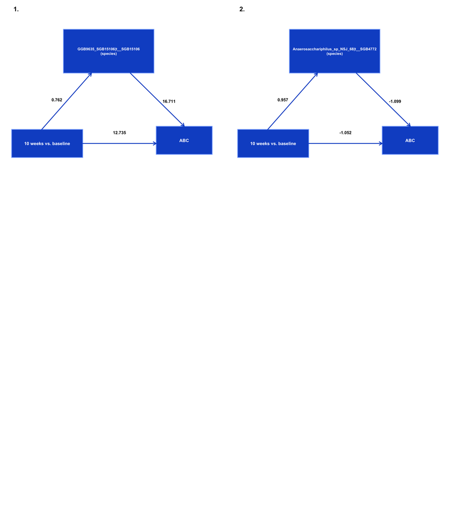

```r
zt_sig <- subset(
  zentangler_all_mediators(zt_fit),
  is.finite(q_primary) & q_primary < 0.25
)

zt_sig <- zt_sig[order(zt_sig$score, decreasing = TRUE, na.last = TRUE), , drop = FALSE]
zt_top5 <- head(zt_sig, 5)

plot_mediator_dag <- function(row_i, rank_i, outcome_label = "ABC") {
  wrap <- function(x, width = 22) paste(strwrap(x, width = width), collapse = "\n")
  fmt  <- function(x) ifelse(is.finite(x), formatC(x, digits = 3, format = "f"), "NA")

  box <- function(xleft, ybottom, xright, ytop, label,
                  fill = "#1155cc", border = "#8fb3ff", cex = 1.1) {
    rect(xleft, ybottom, xright, ytop, col = fill, border = border, lwd = 2)
    text((xleft + xright) / 2, (ybottom + ytop) / 2, label,
         col = "white", cex = cex, font = 2)
  }
  arrow <- function(x0, y0, x1, y1, label, label_x, label_y,
                    col = "#1155cc", lwd = 2.5, cex = 1.2) {
    arrows(x0, y0, x1, y1, length = 0.1, lwd = lwd, col = col)
    text(label_x, label_y, labels = label, cex = cex, font = 2, col = "black")
  }

  mediator_label <- paste0(
    wrap(as.character(row_i$mediator), width = 24),
    "\n(",
    gsub("_", " ", as.character(row_i$omics), fixed = TRUE),
    ")"
  )

  plot.new()
  plot.window(xlim = c(0, 1), ylim = c(0, 1))
  title(main = paste0(rank_i, "."), adj = 0.04, cex.main = 1.8, font.main = 2)

  box(0.03, 0.08, 0.36, 0.26, "10 weeks vs. baseline", cex = 1.25)
  box(0.27, 0.62, 0.69, 0.90, mediator_label, cex = 1.05)
  box(0.70, 0.10, 0.96, 0.28, outcome_label, cex = 1.25)

  ## A-path (exposure -> mediator), B-path (mediator -> outcome), and the score.
  arrow(0.17, 0.26, 0.40, 0.62, fmt(as.numeric(row_i$a)),
        label_x = 0.24, label_y = 0.45)
  arrow(0.58, 0.62, 0.83, 0.28, fmt(as.numeric(row_i$b)),
        label_x = 0.76, label_y = 0.44)
  arrow(0.36, 0.17, 0.70, 0.17, fmt(as.numeric(row_i$score)),
        label_x = 0.53, label_y = 0.24)
}

old_par <- par(no.readonly = TRUE)
on.exit(par(old_par), add = TRUE)

par(
  mfrow = c(3, 2),
  mar = c(1.2, 1.2, 2.2, 1.2),
  oma = c(0, 0, 1, 0),
  xaxs = "i",
  yaxs = "i"
)

for (i in seq_len(nrow(zt_top5))) {
  plot_mediator_dag(
    row_i = zt_top5[i, , drop = FALSE],
    rank_i = i,
    outcome_label = "ABC"
  )
}

if (nrow(zt_top5) < 6) {
  plot.new()
}
```